# Data Visualization: R Project1

### Mohammad Chauhan & Patricia O’brien

This HTML documents the steps for this project so it may be reproduced.

#### Basic Steps to begin the project.

1. Create a GitHub Repository named DV_RProject1
2. Clone the DV_RProject1 Repository into a DV_RProject1 folder in your Data Visualizaiton Folder, all of the project code should go into this repository.
3. Create an RStudio DV_RProject1 Project for the DV_RProject1 folder (this is where you will do your development)
4. Create the following structure in the RStudio DV_RProject1 Project:
- 00 Doc - this is where you put your .Rmd file and related files, if any.
- 01 Data - this contains the details of your data.
- 02 Visualizations - this is where the ggplot programs go.
5. Build dataframes for each of the plots you will have. In this case, we have six.
6. For the first dataframe, which includes all of the data, display a summary and subset of the data in the HTML document.

The following plots are graphed using ggplot visualization techniques. The techniques for this are explained below each plot.

#### Plot 1

```r
source("../01 Data/Dataframe1.R", echo = TRUE)
```

```
##
## > require("jsonlite")
```

```
##
## > require("RCurl")
```

```
##
## > require("ggplot2")
```

```
##
## > df <- data.frame(fromJSON(getURL(URLencode("129.152.144.84:5001/rest/native/?query=\"select * from titanic\""),
## +     httpheader = c(DB = "jdbc:ora ..." ... [TRUNCATED]
##
## > summary(df)
##                                       PASSENGERID  SURVIVED    PCLASS
##  </pre></body></html>Xtext/csvUUTF-8(?N`vPJS:  1   0   :549   1   :216
##  1                                          :  1   1   :342   2   :184
##  10                                         :  1   null:  2   3   :491
##  100                                        :  1              null:  2
##  101                                        :  1
##  102                                        :  1
##  (Other)                                    :887
##                                     NAME         SEX           AGE
##  null                                 :  2   female:314   null   :179
##  Abbing, Mr. Anthony                  :  1   male  :577   24     : 30
##  Abbott, Mr. Rossmore Edward          :  1   null  :  2   22     : 27
##  Abbott, Mrs. Stanton (Rosa Hunt)     :  1                18     : 26
##  Abelson, Mr. Samuel                  :  1                19     : 25
##  Abelson, Mrs. Samuel (Hannah Wizosky):  1                28     : 25
##  (Other)                              :886                (Other):581
##      SIBSP         PARCH          TICKET                  FARE
##  0      :608   0      :678   1601    :  7   8.05000019073486: 43
##  1      :209   1      :118   347082  :  7   13              : 42
##  2      : 28   2      : 80   CA. 2343:  7   7.89580011367798: 38
##  4      : 18   3      :  5   3101295 :  6   7.75            : 34
##  3      : 16   5      :  5   347088  :  6   26              : 31
##  8      :  7   4      :  4   CA 2144 :  6   10.5            : 24
##  (Other):  7   (Other):  3   (Other) :854   (Other)         :681
##          CABIN     EMBARKED
##  null       :689   C   :168
##  B96 B98    :  4   null:  4
##  C23 C25 C27:  4   Q   : 77
##  G6         :  4   S   :644
##  C22 C26    :  3
##  D          :  3
##  (Other)    :186
##
## > head(df)
##   PASSENGERID SURVIVED PCLASS
## 1         414        0      2
## 2         415        1      3
## 3         416        0      3
## 4         417        1      2
## 5         418        1      2
## 6         419        0      2
##                                              NAME    SEX  AGE SIBSP PARCH
## 1                  Cunningham, Mr. Alfred Fleming   male null     0     0
## 2                       Sundman, Mr. Johan Julian   male   44     0     0
## 3         Meek, Mrs. Thomas (Annie Louise Rowley) female null     0     0
## 4 Drew, Mrs. James Vivian (Lulu Thorne Christian) female   34     1     1
## 5                   Silven, Miss. Lyyli Karoliina female   18     0     2
## 6                      Matthews, Mr. William John   male   30     0     0
##              TICKET             FARE CABIN EMBARKED
## 1            239853                0  null        S
## 2 STON/O 2. 3101269 7.92500019073486  null        S
## 3            343095 8.05000019073486  null        S
## 4             28220             32.5  null        S
## 5            250652               13  null        S
## 6             28228               13  null        S
##
## > require(extrafont)
```

```
## Registering fonts with R
```

```
##
## > ggplot(data = df, aes(x = AGE, y = FARE), color = SEX) +
## +     coord_cartesian() + scale_x_continuous() + scale_y_continuous() +
## +     labs(title  .... [TRUNCATED]
```

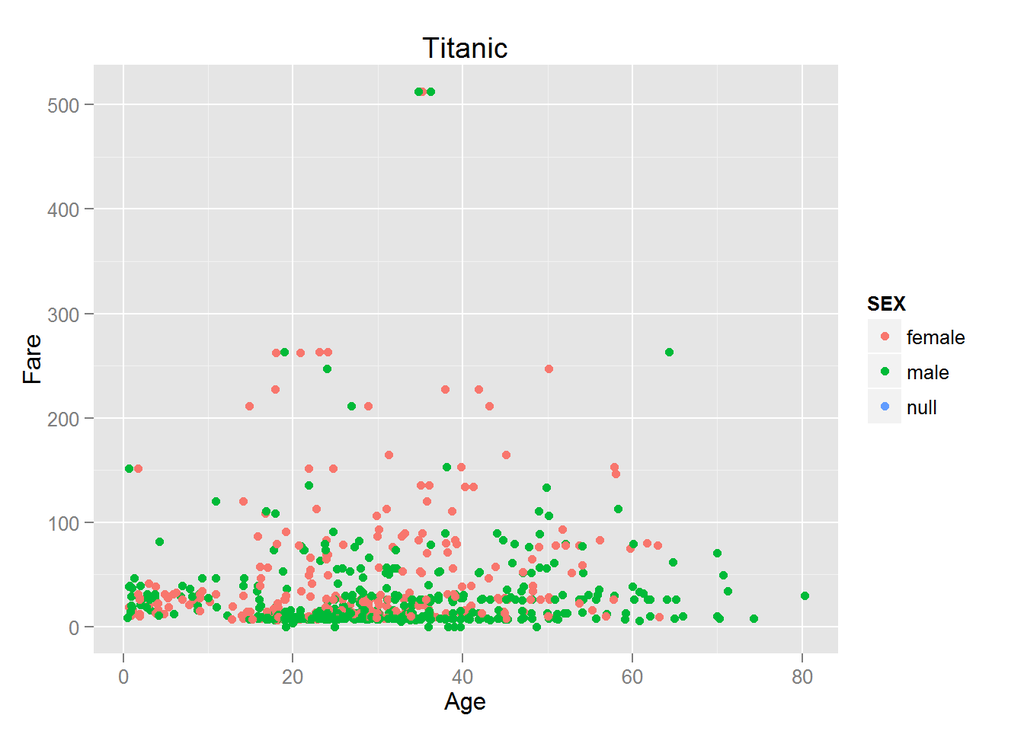

First load in the dataframe and include the passengers who had null as their sex. Then start a plot of age on the x-axis and fare on the y-axis. Declare the x and y axises as continuous because age and fare are continuous variables. Set your title and label the x-axis as “Age” and the y-axis as “Fare”.

#### Plot 2

```r
source("../01 Data/Dataframe2.R", echo = TRUE)
```

```
##
## > require("jsonlite")
##
## > require("RCurl")
##
## > require("ggplot2")
##
## > df <- data.frame(fromJSON(getURL(URLencode("129.152.144.84:5001/rest/native/?query=\"select * from titanic where sex is not null\""),
## +     httphea .... [TRUNCATED]
##
## > require(extrafont)
##
## > ggplot(data = df, aes(x = AGE, y = FARE), color = SEX) +
## +     coord_cartesian() + scale_x_continuous() + scale_y_continuous() +
## +     labs(title  .... [TRUNCATED]
```

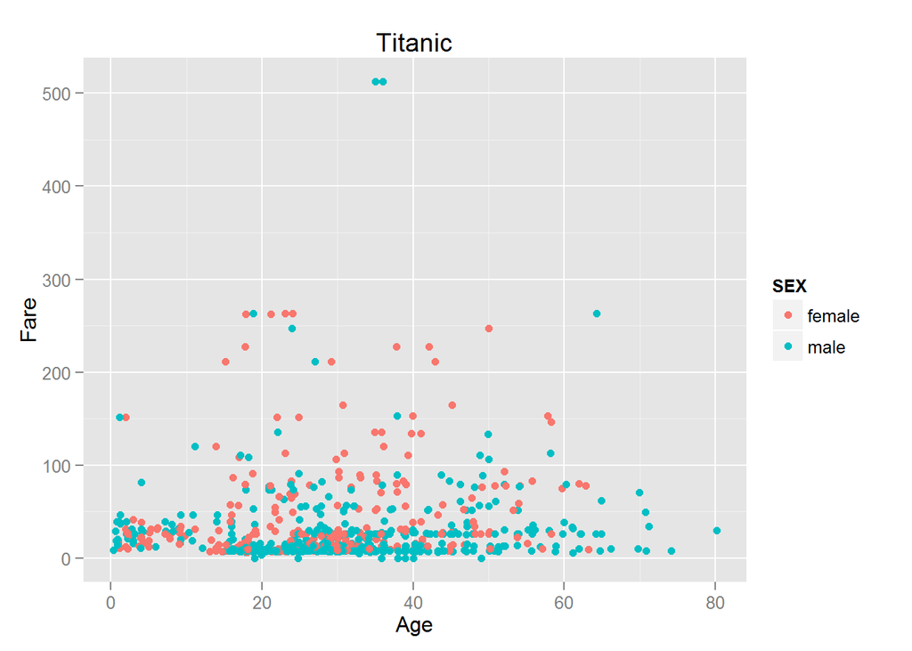

First load in the dataframe and makes sure to not to include the passengers who had null as their sex. Then start a plot of age on the x-axis and fare on the y-axis. Declare the x and y axises as continuous because age and fare are continuous variables. Set your title and label the x-axis as “Age” and the y-axis as “Fare”.

#### Plot 3

```r
source("../01 Data/Dataframe3.R", echo = TRUE)
```

```
##
## > require("jsonlite")
##
## > require("RCurl")
##
## > require("ggplot2")
##
## > df <- data.frame(fromJSON(getURL(URLencode("129.152.144.84:5001/rest/native/?query=\"select * from titanic where sex is not null\""),
## +     httphea .... [TRUNCATED]
##
## > require(extrafont)
##
## > ggplot() + coord_cartesian() + scale_x_discrete() +
## +     scale_y_continuous() + labs(title = "Titanic") + labs(x = "SURVIVED",
## +     y = paste("F ..." ... [TRUNCATED]
```

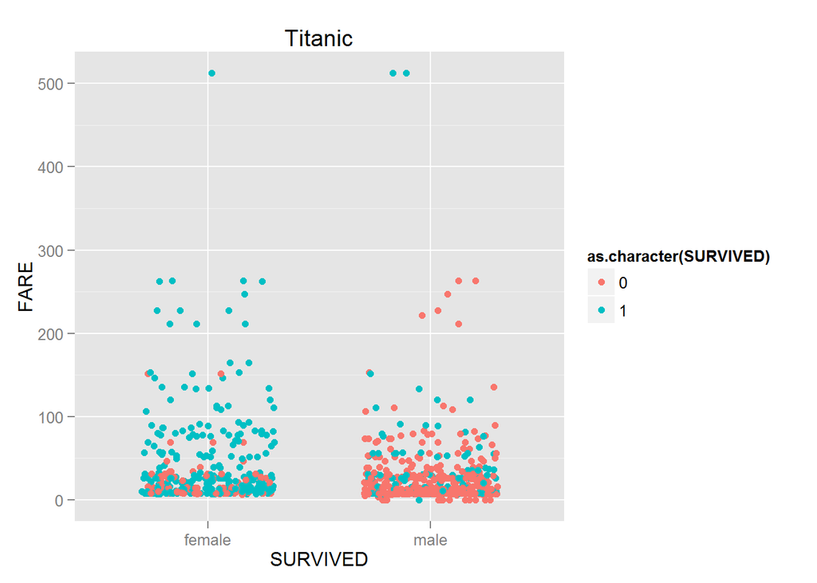

First load in the dataframe and makes sure to not to include the passengers who had null as their sex. Declare the x-axis as discrete and the y-axis as continuous because age and fare are continuous variables. Set your title and label the the x-axis as “Survived” and the y-axis as “Fare.” Add a layer and make sure to convert the fare values on the y-axis from strings to integers. Set the color to group by people who survived and didn’t.

#### Plot 4

```r
source("../01 Data/Dataframe4.R", echo = TRUE)
```

```
##
## > require("jsonlite")
##
## > require("RCurl")
##
## > require("ggplot2")
##
## > df <- data.frame(fromJSON(getURL(URLencode("129.152.144.84:5001/rest/native/?query=\"select * from titanic where sex is not null\""),
## +     httphea .... [TRUNCATED]
##
## > require(extrafont)
##
## > ggplot() + coord_cartesian() + scale_x_discrete() +
## +     scale_y_continuous() + facet_grid(PCLASS ~ SURVIVED, labeller = label_both) +
## +     labs .... [TRUNCATED]
```

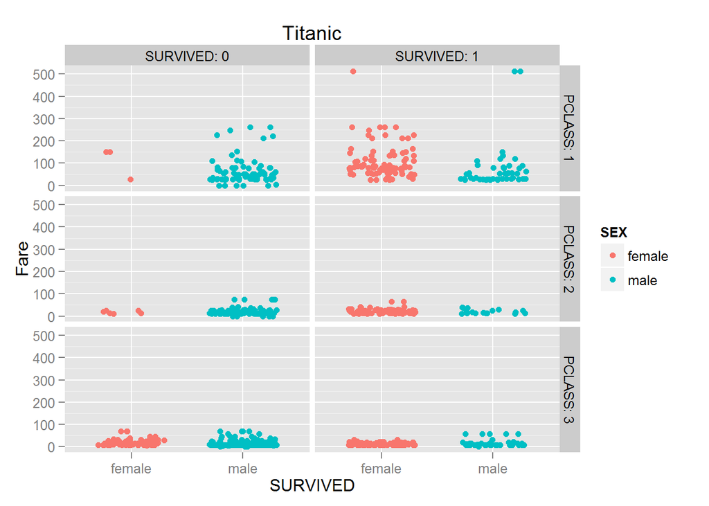

First load in the dataframe and makes sure to not to include the passengers who had null as their sex. Declare the x-axis as discrete and the y-axis as continuous because age and fare are continuous variables. Partition the plot into a 2D matrix of panels based on passenger class and survival. Set the title and label the the x-axis as “Survived” and the y-axis as “Fare.” Add a layer and make sure to convert the fare values on the y-axis from strings to integers. Set the color to group by sex.

#### Plot 5

```r
source("../01 Data/Dataframe5.R", echo = TRUE)
```

```
##
## > require("jsonlite")
##
## > require("RCurl")
##
## > require("ggplot2")
##
## > df <- data.frame(fromJSON(getURL(URLencode("129.152.144.84:5001/rest/native/?query=\"select * from titanic where age <= 10\""),
## +     httpheader =  .... [TRUNCATED]
##
## > require(extrafont)
##
## > ggplot() + coord_cartesian() + scale_x_discrete() +
## +     scale_y_continuous() + facet_grid(PCLASS ~ SURVIVED, labeller = label_both) +
## +     labs .... [TRUNCATED]
```

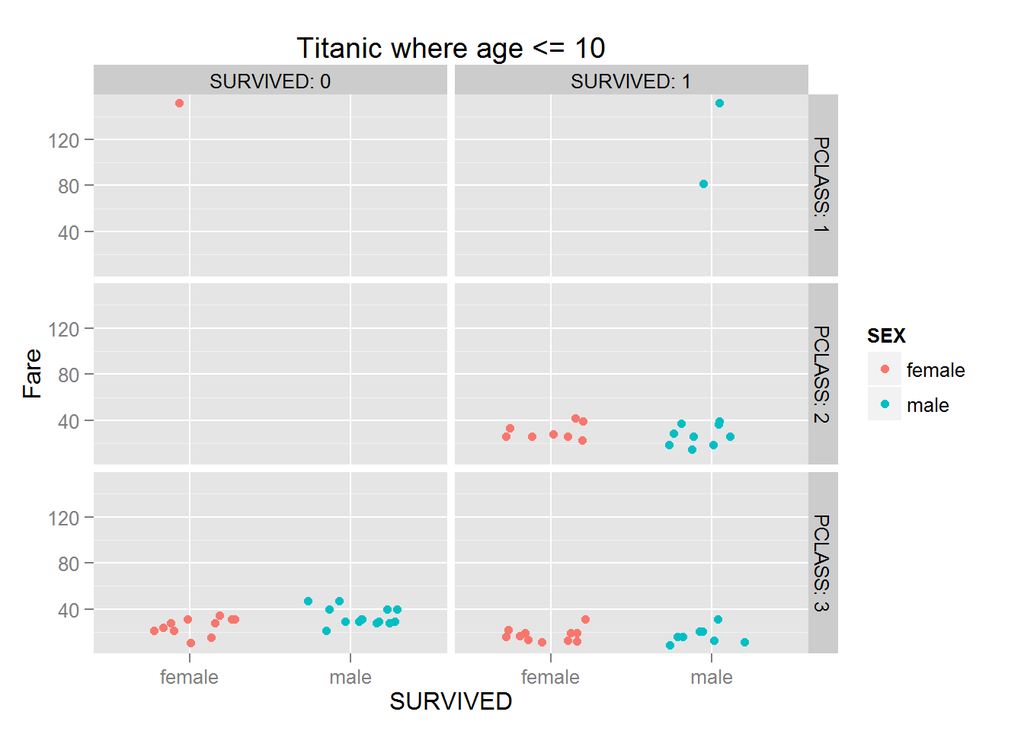

First load in the dataframe and makes sure only people who are ten years old and younger are included in the dataframe. Declare the x-axis as discrete and the y-axis as continuous because age and fare are continuous variables. Partition the plot into a 2D matrix of panels based on passenger class and survival. Set the title and label the the x-axis as “Survived” and the y-axis as “Fare.” Add a layer and make sure to convert the fare values on the y-axis from strings to integers. Set the color to group by sex.

#### Plot 6

```r
source("../01 Data/Dataframe6.R", echo = TRUE)
```

```
##
## > require("jsonlite")
##
## > require("RCurl")
##
## > require("ggplot2")
##
## > df <- data.frame(fromJSON(getURL(URLencode("129.152.144.84:5001/rest/native/?query=\"select * from Titanic where pclass is not null\""),
## +     http .... [TRUNCATED]
##
## > require(extrafont)
##
## > ggplot() + coord_cartesian() + scale_x_discrete() +
## +     scale_y_continuous() + facet_grid(~PCLASS, labeller = label_both) +
## +     labs(title = " ..." ... [TRUNCATED]
```

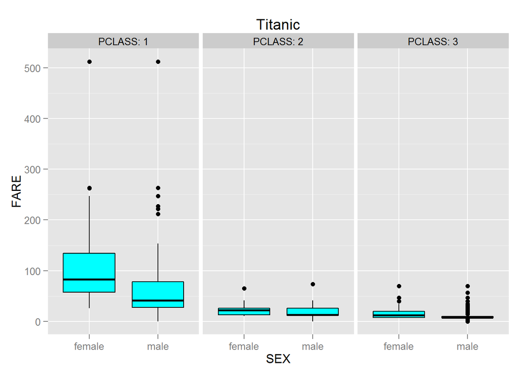

This data is displayed in a box plot. A box plot displays the distibution of the data based on five measurements: minimum, first quartile, median, third quartile, and maximum. These box plots show the distribution of fares for males and females in each passenger class.

As seen in the box plots, passengers in passnger class 1 had a much larger distribution of fares than the other two classes. This may be because as the passenger class gets better, more amenities are offered or could be requested. Different requests may and amenities in the higher class may have caused the distribution in fares between the two genders and the three classes.